# Assignment 9

Samantha Ingram

2022-10-31

In this assignment I will be looking at factors that contribute to a students admission into Graduate school.

First I will load a few handy packages:

```r
library(tidyverse)
library(modelr)
library(easystats)
library(palmerpenguins)
library(GGally)
library(kableExtra)
library(broom)
theme_set(theme_minimal())
```

```r
#Loading the data set
df <- read_csv("./Data/GradSchool_Admissions.csv")

df %>% glimpse
```

```
## Rows: 400
## Columns: 4
## $ admit <dbl> 0, 1, 1, 1, 0, 1, 1, 0, 1, 0, 0, 0, 1, 0, 1, 0, 0, 0, 0, 1, 0, 1…
## $ gre   <dbl> 380, 660, 800, 640, 520, 760, 560, 400, 540, 700, 800, 440, 760,…
## $ gpa   <dbl> 3.61, 3.67, 4.00, 3.19, 2.93, 3.00, 2.98, 3.08, 3.39, 3.92, 4.00…
## $ rank  <dbl> 3, 3, 1, 4, 4, 2, 1, 2, 3, 2, 4, 1, 1, 2, 1, 3, 4, 3, 2, 1, 3, 2…
```

Making it True or False

```r
df$admit <- df$admit %>% as.logical()
```

Taking a closer look at how variables interact:

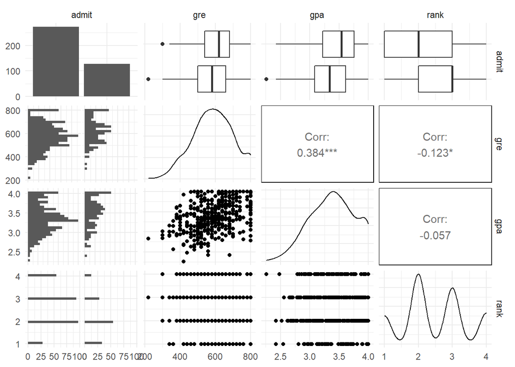

```r
df %>%
  ggpairs()
```

Plotting gpa and gre and how admittance falls into those factors and facet wrapping by the rank of school type.

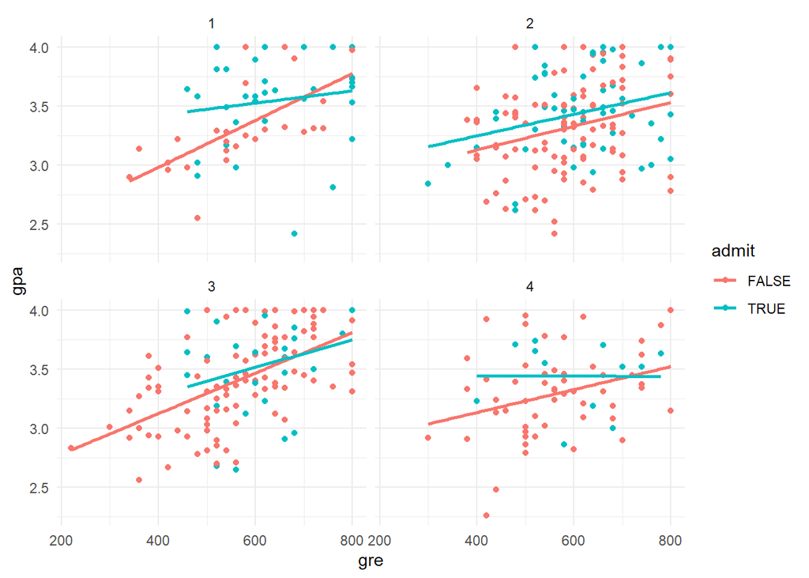

```r
df %>%
  ggplot(aes(y=gpa, x= gre, color=admit))+
  geom_point()+
  geom_smooth(method="lm", se=FALSE)+
  facet_wrap(~rank)
```

Plotting a boxplot to get an idea of the admittance rate when comparing rank to gpa:

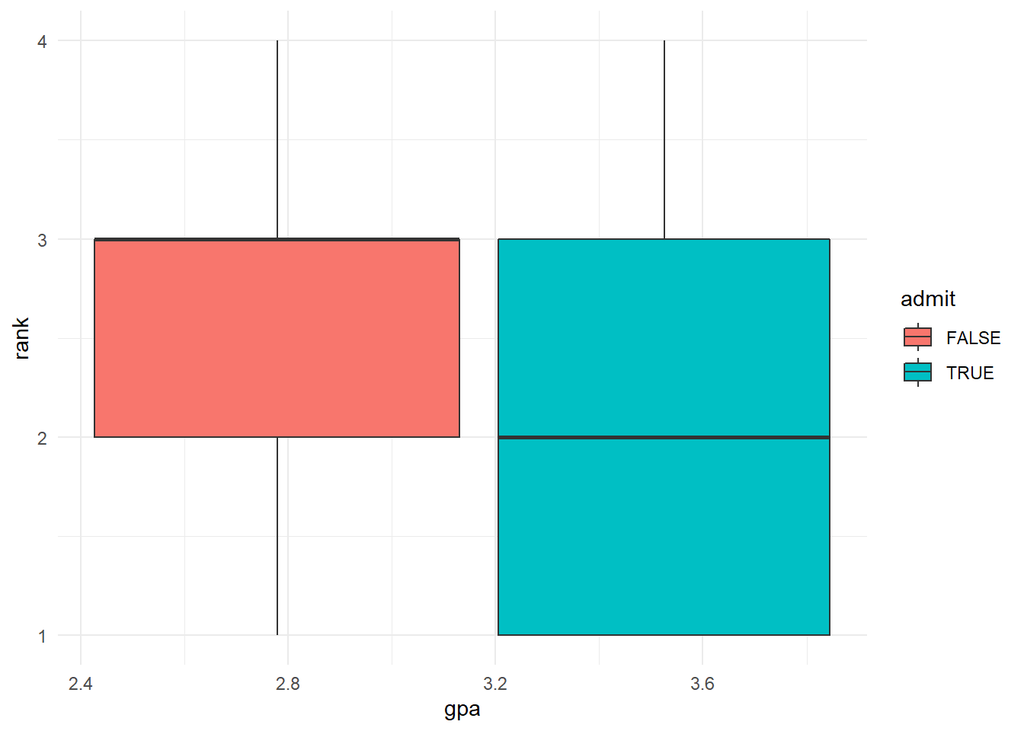

```r
df %>%
  ggplot(aes(y=rank, x =gpa, fill=admit))+
  geom_boxplot()
```

Trying out a couple different models:

```r
names(df)
```

```
## [1] "admit" "gre"   "gpa"   "rank"
```

```r
mod1 <- glm(data=df, formula= admit~ gpa, family= "binomial")
tidy(mod1) %>%
  filter(p.value <0.05)
```

```
## # A tibble: 2 × 5
##   term        estimate std.error statistic   p.value
##   <chr>          <dbl>     <dbl>     <dbl>     <dbl>
## 1 (Intercept)    -4.36     1.04      -4.21 0.0000257
## 2 gpa             1.05     0.299      3.52 0.000437
```

```r
mod2 <- glm(data=df, formula= admit~gre, family="binomial")
tidy(mod2)  %>%
  filter(p.value <0.05)
```

```
## # A tibble: 2 × 5
##   term        estimate std.error statistic    p.value
##   <chr>          <dbl>     <dbl>     <dbl>      <dbl>
## 1 (Intercept) -2.90     0.606        -4.79 0.00000169
## 2 gre          0.00358  0.000986      3.63 0.000280
```

```r
mod3 <- glm(data=df, formula= admit~gpa*gre, family= "binomial")
tidy(mod3) %>%
  filter(p.value<0.05)
```

```
## # A tibble: 1 × 5
##   term        estimate std.error statistic p.value
##   <chr>          <dbl>     <dbl>     <dbl>   <dbl>
## 1 (Intercept)    -13.8      5.87     -2.35  0.0187
```

```r
mod4 <- glm(data=df, formula= admit~gpa+gre, family= "binomial")
tidy(mod4) %>%
  filter(p.value<0.05)
```

```
## # A tibble: 3 × 5
##   term        estimate std.error statistic    p.value
##   <chr>          <dbl>     <dbl>     <dbl>      <dbl>
## 1 (Intercept) -4.95      1.08        -4.60 0.00000415
## 2 gpa          0.755     0.320        2.36 0.0182
## 3 gre          0.00269   0.00106      2.54 0.0109
```

```r
mod5 <- glm(data=df, formula= admit~rank, family= "binomial")
tidy(mod5) %>%
  filter(p.value<0.05)
```

```
## # A tibble: 2 × 5
##   term        estimate std.error statistic    p.value
##   <chr>          <dbl>     <dbl>     <dbl>      <dbl>
## 1 (Intercept)    0.637     0.306      2.08 0.0375
## 2 rank          -0.586     0.124     -4.73 0.00000226
```

```r
mod6 <- glm(data=df, formula= rank~gre + gpa)
tidy(mod6) %>%
  filter(p.value<0.05)
```

```
## # A tibble: 2 × 5
##   term         estimate std.error statistic  p.value
##   <chr>           <dbl>     <dbl>     <dbl>    <dbl>
## 1 (Intercept)  3.16      0.430         7.34 1.24e-12
## 2 gre         -0.000972  0.000441     -2.20 2.80e- 2
```

```r
full_mod <- glm(data=df, formula=admit~gre+gpa+rank)
tidy(full_mod) %>%
  filter(p.value<0.05)
```

```
## # A tibble: 3 × 5
##   term   estimate std.error statistic    p.value
##   <chr>     <dbl>     <dbl>     <dbl>      <dbl>
## 1 gre    0.000442  0.000210      2.11 0.0358
## 2 gpa    0.151     0.0634        2.38 0.0176
## 3 rank  -0.110     0.0238       -4.61 0.00000548
```

Now to compare all the models to each other:

```r
comparisons <- compare_performance(mod1,mod2,mod3,mod4,mod5, mod6,full_mod, rank=TRUE)

comparisons
```

```
## # Comparison of Model Performance Indices
##
## Name     | Model |  RMSE | Sigma | AIC weights | BIC weights | Performance-Score
## --------------------------------------------------------------------------------
## mod5     |   glm | 0.451 | 1.093 |       0.915 |       0.985 |            75.06%
## full_mod |   glm | 0.443 | 0.445 |       0.001 |    3.11e-06 |            50.03%
## mod3     |   glm | 0.453 | 1.098 |       0.043 |    8.46e-04 |            25.95%
## mod4     |   glm | 0.455 | 1.100 |       0.033 |       0.005 |            25.65%
## mod2     |   glm | 0.458 | 1.105 |       0.005 |       0.006 |            24.56%
## mod1     |   glm | 0.458 | 1.106 |       0.003 |       0.004 |            24.41%
## mod6     |   glm | 0.936 | 0.940 |   2.43e-133 |   4.83e-135 |             6.30%
```

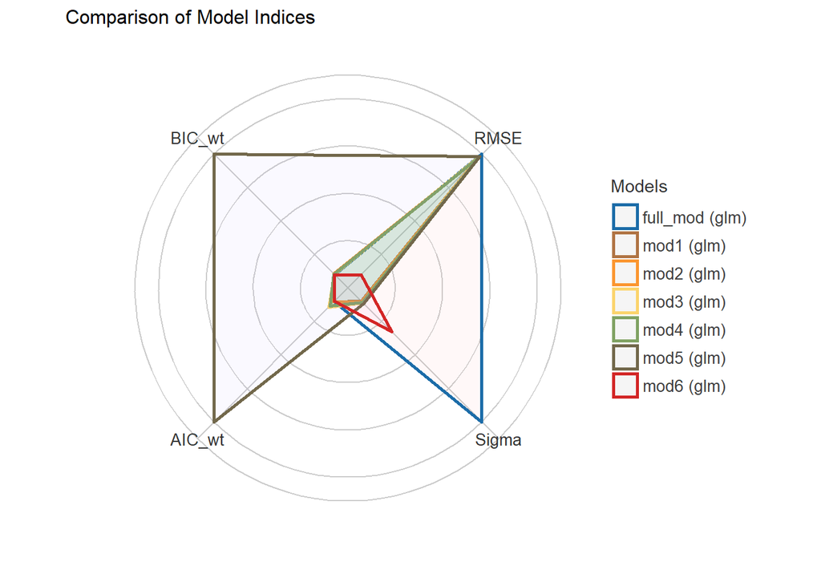

```r
comparisons %>% plot
```

So we see that mod5 is the best model for this data at this point. It is pretty simple in comparison to full_mod, which is pretty complex. So I will stick with mod5 for gathering predictions.

Predictions comparing full_mod and mod5 together..just for fun!

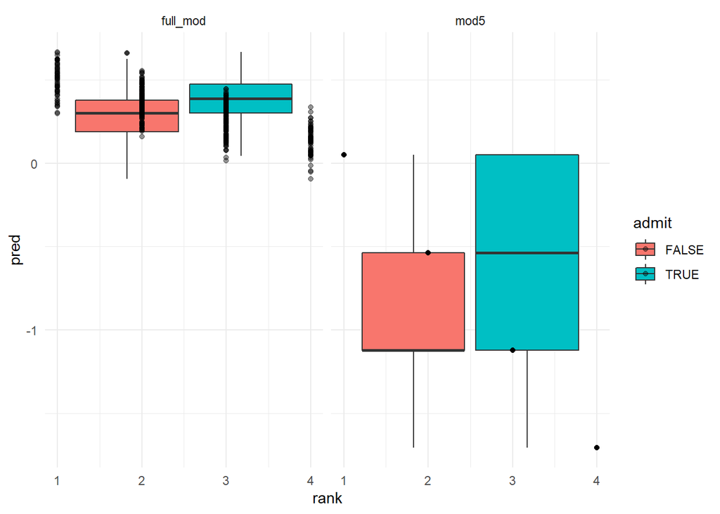

```r
df %>% gather_predictions(mod5,full_mod) %>%
  ggplot(aes(x=rank, y=pred, fill=admit))+
  geom_boxplot()+
  geom_point(alpha=.4, color="black")+
  facet_wrap(~model)
```

It seems like mod5 is more accurate at predicting than full_mod, but I could be misunderstanding. I was getting a little “overthinky” when I got to this point.

Report:

```r
report(mod5)
```

```
## We fitted a logistic model (estimated using ML) to predict admit with rank
## (formula: admit ~ rank). The model's explanatory power is weak (Tjur's R2 =
## 0.06). The model's intercept, corresponding to rank = 0, is at 0.64 (95% CI
## [0.04, 1.24], p = 0.038). Within this model:
##
##   - The effect of rank is statistically significant and negative (beta = -0.59,
## 95% CI [-0.83, -0.35], p < .001; Std. beta = -0.55, 95% CI [-0.79, -0.33])
##
## Standardized parameters were obtained by fitting the model on a standardized
## version of the dataset. 95% Confidence Intervals (CIs) and p-values were
## computed using a Wald z-distribution approximation.
```